# ChIP-seq In Bioconductor part4

Rockefeller University, Bioinformatics Resource Centre

http://rockefelleruniversity.github.io/RU_ChIPseq/

# Data

In todays session we will continue to review the Myc ChIPseq we were working on in our last sessions.

This include Myc ChIP-seq for MEL and Ch12 celllines.

Information and files for the [Myc ChIPseq in MEL cell line can be found here](https://www.encodeproject.org/experiments/ENCSR000EUA/)

Information and files for the [Myc ChIPseq in Ch12 cell line can be found here](https://www.encodeproject.org/experiments/ENCSR000ERN/)

# Data

I have provided peakcalls from MACS2 following the processing steps outlined in our last session.

Peak calls for Myc in MEL and Ch12 cellines can be found in

**Data/peaks/**

# Mapping Transcription factor binding and epigenetic states

With the release of Encode’s wide scale mapping of transcription factor binding sites or epigenetic states and the advent of multiplexing technologies for high throughput sequencing, in has become common practice to have replicated ChIP-seq experiments so as to have higher confidence in identified epigenetic events.

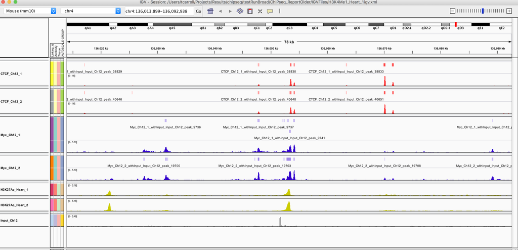

# Myc ChIPseq in Mel and Ch12 cell-lines.

We have been working to process and a characterise Myc ChIPseq replicate in the Mel cell-line to gain an understanding of a potential role for Myc in Mel cell-line.

In this session we will look at how we can define a high confidence/reproducible set of Myc peaks in the Mel cellline as well as identify Myc binding events unique or common between Mel and Ch12 cell-lines.

# Reading in a set of peaks

We can loop through our tab seperated files (disguised as *.xls* functions) and import them into R as a list of data.frames using a loop.

```r
macsPeaks_DF <- list()
for(i in 1:length(peakFiles)){
  macsPeaks_DF[[i]] <- read.delim(peakFiles[i],
                                  comment.char="#")
}
length(macsPeaks_DF)
```

```
## [1] 4
```

# Reading in a set of peaks

We will want to assign a sensible set of names to our peak calls.

We can use the **gsub()** and **basename()** function with our file names to create some samplenames.

The **basename()** function accepts a file path (such as the path to our bam files) and returns just the file name (removing directory paths).

The **gsub()** function accepts the text to replace, the replacement text and a character vector to replace within.

```r
fileNames <- basename(peakFiles)
fileNames
```

```
## [1] "ch12_1_peaks.xls" "ch12_2_peaks.xls" "Mel_1_peaks.xls"
## [4] "Mel_2_peaks.xls"
```

```r
sampleNames <- gsub("_peaks.xls","",fileNames)
sampleNames
```

```
## [1] "ch12_1" "ch12_2" "Mel_1"  "Mel_2"
```

# GRangesList objects

The GRangesList object can behave just as our standard lists. Here we use the **lengths()** function to a get the number of peaks in each replicate.

```r
lengths(macsPeaks_GRL)
```

```
## ch12_1 ch12_2  Mel_1  Mel_2
##  13910  28420  13777  13512
```

# GRangesList objects

Now we have our GRangesList we can extract the peak calls for the Mel replicates.

```r
Mel_1_Peaks <- macsPeaks_GRL$Mel_1
Mel_2_Peaks <- macsPeaks_GRL$Mel_2
length(Mel_1_Peaks)
```

```
## [1] 13777
```

```r
length(Mel_2_Peaks)
```

```
## [1] 13512
```

# Finding unique peaks

We can extract peak calls unique to replicate 1 or 2 using the **%over%** operator.

```r
Mel_1_Unique <- Mel_1_Peaks[!Mel_1_Peaks %over% Mel_2_Peaks]
Mel_2_Unique <- Mel_2_Peaks[!Mel_2_Peaks %over% Mel_1_Peaks]
length(Mel_1_Unique)
```

```
## [1] 4668
```

```r
length(Mel_2_Unique)
```

```
## [1] 4263
```

```r
export.bed(Mel_1_Unique,"Mel_1_Unique.bed")
export.bed(Mel_2_Unique,"Mel_2_Unique.bed")
```

# Finding unique peaks

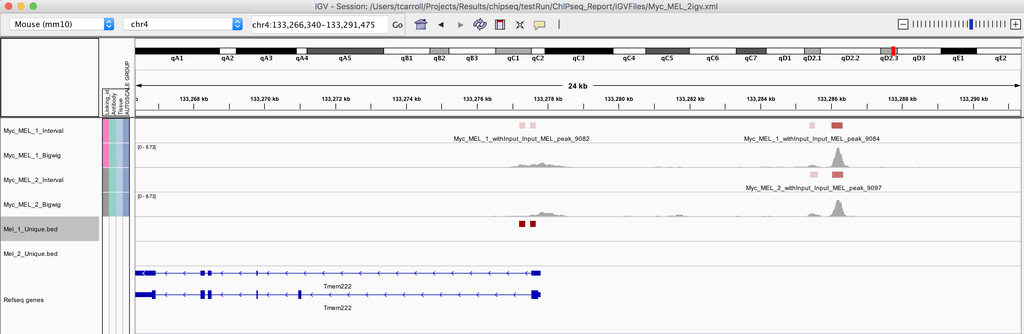

# Finding common peaks

Similarly we can extract peak calls common to replicate 1 or 2.

The numbers in common however differ. This is because 2 peak calls in one sample can overlap 1 peak call in the other replicate.

```r
Mel_1_Common <- Mel_1_Peaks[Mel_1_Peaks %over% Mel_2_Peaks]
Mel_2_Common <- Mel_2_Peaks[Mel_2_Peaks %over% Mel_1_Peaks]
length(Mel_1_Common)
```

```
## [1] 9109
```

```r
length(Mel_2_Common)
```

```
## [1] 9249
```

```r
export.bed(Mel_1_Common,"Mel_1_Common.bed")
export.bed(Mel_2_Common,"Mel_2_Common.bed")
```

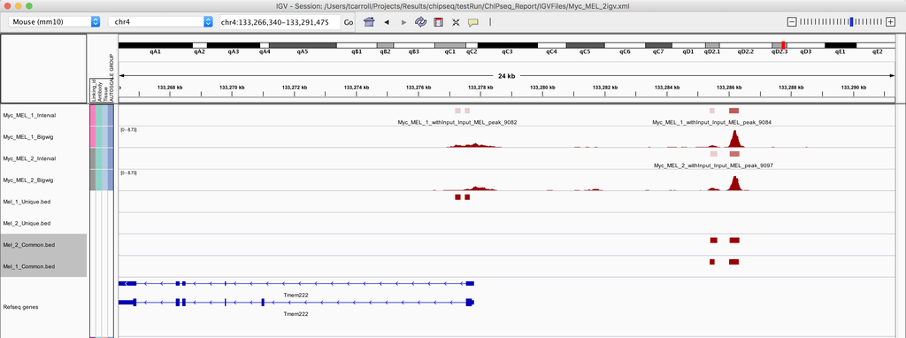

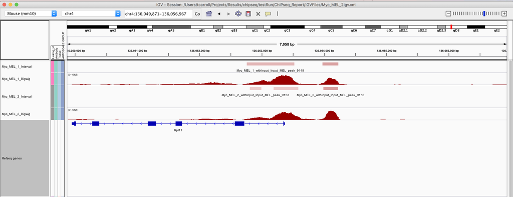

# Defining a consensus, non-redundant set.

We can then use the **reduce()** function to collapse our peaks into non-redundant, distinct peaks representing peaks present in any sample.

```r
allPeaksSet_nR <- reduce(allPeaksSet_Overlapping)
allPeaksSet_nR
```

```
## GRanges object with 38937 ranges and 0 metadata columns:
##           seqnames               ranges strand
##              <Rle>            <IRanges>  <Rle>
##       [1]     chr1   [4416806, 4417001]      *
##       [2]     chr1   [4490620, 4490773]      *
##       [3]     chr1   [4671488, 4671836]      *
##       [4]     chr1   [4785341, 4785781]      *
##       [5]     chr1   [4857628, 4857783]      *
##       ...      ...                  ...    ...
##   [38933]     chrY [90741011, 90741723]      *
##   [38934]     chrY [90741934, 90743197]      *
##   [38935]     chrY [90744329, 90744494]      *
##   [38936]     chrY [90825195, 90825796]      *
##   [38937]     chrY [90828711, 90828830]      *
##   -------
##   seqinfo: 21 sequences from an unspecified genome; no seqlengths
```

```r
export.bed(allPeaksSet_nR,"allPeaksSet_nR.bed")
```

# Defining a common set of peaks.

With our newly defined non-redundant peak set we can now identify from this set which peaks were present in both our replicates using the **%over%** operator and a logical expression.

```r
commonPeaks <- allPeaksSet_nR[allPeaksSet_nR %over% Mel_1_Peaks &
                               allPeaksSet_nR %over% Mel_2_Peaks]
commonPeaks
```

```
## GRanges object with 8888 ranges and 0 metadata columns:
##          seqnames                 ranges strand
##             <Rle>              <IRanges>  <Rle>
##      [1]     chr1     [4785341, 4785781]      *
##      [2]     chr1     [7397557, 7398093]      *
##      [3]     chr1     [9545120, 9545648]      *
##      [4]     chr1     [9943560, 9943856]      *
##      [5]     chr1     [9943893, 9944649]      *
##      ...      ...                    ...    ...
##   [8884]     chrX [166535216, 166535529]      *
##   [8885]     chrX [168673273, 168673855]      *
##   [8886]     chrX [169047634, 169047962]      *
##   [8887]     chrY [  1245573,   1245871]      *
##   [8888]     chrY [  1286522,   1286823]      *
##   -------
##   seqinfo: 21 sequences from an unspecified genome; no seqlengths
```

```r
export.bed(commonPeaks,"commonPeaks.bed")
```

[figure not shown]

# Defining a unique set of peaks.

Similarly we can identify which peaks are present only in one replicate.

```r
mel1_Only <- allPeaksSet_nR[allPeaksSet_nR %over% Mel_1_Peaks &
                             !allPeaksSet_nR %over% Mel_2_Peaks]
mel2_Only <- allPeaksSet_nR[!allPeaksSet_nR %over% Mel_1_Peaks &
                             allPeaksSet_nR %over% Mel_2_Peaks]
length(mel1_Only)
```

```
## [1] 4445
```

```r
length(mel2_Only)
```

```
## [1] 4185
```

```r
export.bed(mel1_Only,"mel1_Only.bed")
export.bed(mel2_Only,"mel2_Only.bed")
```

# Complex overlaps.

When working with larger numbers of peaks we will often define a logical matrix describing in which samples our non-redundant peaks were present.

First then we use a loop to generate a logical vector for the occurence of non-redundant peaks in each sample.

```r
overlap <- list()
for(i in 1:length(macsPeaks_GRL)){
  overlap[[i]] <- allPeaksSet_nR %over% macsPeaks_GRL[[i]]
}
overlap[[1]][1:2]
```

```
## [1] FALSE  TRUE
```

# Complex overlaps.

We can add the matrix back into the metadata columns of our **GRanges()** of non-redundant peaks using the **mcols()** accessor.

Now we have our non-redundant peaks and the occurence of these peaks in every sample we can easily identify peaks unique or common to replicates and conditions/cell-lines.

```r
mcols(allPeaksSet_nR) <- overlapMatrix
allPeaksSet_nR[1:2,]
```

```
## GRanges object with 2 ranges and 4 metadata columns:
##       seqnames             ranges strand |    ch12_1    ch12_2     Mel_1
##          <Rle>          <IRanges>  <Rle> | <logical> <logical> <logical>
##   [1]     chr1 [4416806, 4417001]      * |     FALSE      TRUE     FALSE
##   [2]     chr1 [4490620, 4490773]      * |      TRUE     FALSE     FALSE
##           Mel_2
##       <logical>
##   [1]     FALSE
##   [2]     FALSE
##   -------
##   seqinfo: 21 sequences from an unspecified genome; no seqlengths
```

# Complex overlaps.

```r
vennCounts(mcols(allPeaksSet_nR))
```

```
##    ch12_1 ch12_2 Mel_1 Mel_2 Counts
## 1       0      0     0     0      0
## 2       0      0     0     1   3361
## 3       0      0     1     0   2435
## 4       0      0     1     1   3876
## 5       0      1     0     0  13042
## 6       0      1     0     1    378
## 7       0      1     1     0   1275
## 8       0      1     1     1   1195
## 9       1      0     0     0   1446
## 10      1      0     0     1     46
## 11      1      0     1     0     24
## 12      1      0     1     1     91
## 13      1      1     0     0   6931
## 14      1      1     0     1    400
## 15      1      1     1     0    711
## 16      1      1     1     1   3726
## attr(,"class")
## [1] "VennCounts"
```

[figure not shown]

# High confidence unique peaks.

```r
ch12_HC_UniquePeaks <- allPeaksSet_nR[
  rowSums(as.data.frame(
    mcols(allPeaksSet_nR)[,c("ch12_1","ch12_2")])) >= 2 &
  rowSums(as.data.frame(
    mcols(allPeaksSet_nR)[,c("Mel_1","Mel_2")])) == 0
  ]
export.bed(ch12_HC_UniquePeaks,"ch12_HC_UniquePeaks.bed")
ch12_HC_UniquePeaks[1,]
```

```
## GRanges object with 1 range and 4 metadata columns:
##       seqnames             ranges strand |    ch12_1    ch12_2     Mel_1
##          <Rle>          <IRanges>  <Rle> | <logical> <logical> <logical>
##   [1]     chr1 [4671488, 4671836]      * |      TRUE      TRUE     FALSE
##           Mel_2
##       <logical>
##   [1]     FALSE
##   -------
##   seqinfo: 21 sequences from an unspecified genome; no seqlengths
```

# Finding differential regions.

Identifying peaks specific to cell-lines or conditions however does not capture the full range of changes in epigenetic events.

To identify differences in epigenetic events we can attempty to quantify the changes in fragment abundance from IP samples across our non-redundant set of peaks.

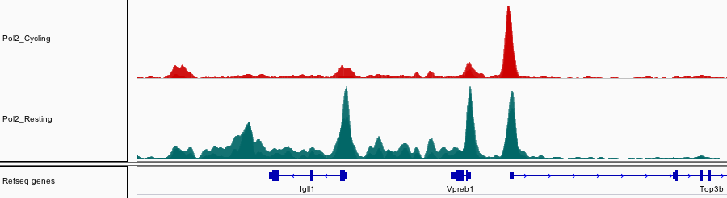

[figure not shown]

# Counting regions.

We will count from our aligned BAM files to quantify IP fragments.

As we have seen previously we can use the **BamFileList()** function to specify which BAMs to count and importantly, to control memory we specify the number of reads to be held in memory at one time using the **yield()** parameter.

```r
library(Rsamtools)

bams <- c("~/Projects/Results/chipseq/testRun/BAMs/Sorted_Myc_Ch12_1.bam",
          "~/Projects/Results/chipseq/testRun/BAMs/Sorted_Myc_Ch12_2.bam",
          "~/Projects/Results/chipseq/testRun/BAMs/Sorted_Myc_Mel_1.bam",
          "~/Projects/Results/chipseq/testRun/BAMs/Sorted_Myc_Mel_2.bam")
bamFL <- BamFileList(bams,yieldSize = 5000000)
bamFL
```

```
## BamFileList of length 4
## names(4): Sorted_Myc_Ch12_1.bam ... Sorted_Myc_Mel_2.bam
```

# Differential regions using DESeq2

To assess changes in ChIP-seq signal across cell-lines we will use the **DESeq2** package.

The DESeq2 package contains a workflow for assessing local changes in fragment/read abundance between replicated conditions. This workflow includes normalisation, variance estimation, outlier removal/replacement as well as significance testing suited to high throughput sequencing data (ie. integer counts).

To make use of DESeq2 workflow we must first create a data.frame of conditions of interest with rownames set as our BAM file names.

```r
metaDataFrame <- data.frame(CellLine=c("Ch12","Ch12","Mel","Mel"))
rownames(metaDataFrame) <- colnames(myMycCounts)
metaDataFrame
```

```
##                       CellLine
## Sorted_Myc_Ch12_1.bam     Ch12
## Sorted_Myc_Ch12_2.bam     Ch12
## Sorted_Myc_Mel_1.bam       Mel
## Sorted_Myc_Mel_2.bam       Mel
```

# Differential regions using DESeq2

We can now run the DESeq2 workflow on our **DESeq2** object using the **DESeq()** function.

```r
deseqMyc <- DESeq(deseqMyc)
```

# Differential regions using DESeq2

We can extract our information of differential regions using the **results()** function.

We provide to the **results()** function the **DESeq2** object, the comparison of interest to the **contrast** parameter and the type of output to return to the **format** parameter.

The comparison to **contrast** parameter is provided as a vector of length3 including the metadata column of interest and groups to test.

We can sort the results by pvalue using the **order()** function to rank by the most significant changes.

```r
MelMinusCh12 <- results(deseqMyc,
                        contrast = c("CellLine","Mel","Ch12"),
                        format="GRanges")
MelMinusCh12 <- MelMinusCh12[order(MelMinusCh12$pvalue),]
class(MelMinusCh12)
```

```
## [1] "GRanges"
## attr(,"package")
## [1] "GenomicRanges"
```

# Differential regions using DESeq2

We can now filter our non-redundant peaks to those with significantly more signal in Mel or Ch12 cell-lines by filtering by log2FoldChange and padj (p-value adjusted for multiple correction) less than 0.05.

```r
MelMinusCh12Filt <- MelMinusCh12[!is.na(MelMinusCh12$pvalue) | !is.na(MelMinusCh12$padj)]
UpinMel <-  MelMinusCh12[MelMinusCh12$padj < 0.05 & MelMinusCh12$log2FoldChange > 0]
DowninMel <-  MelMinusCh12[MelMinusCh12$padj < 0.05 & MelMinusCh12$log2FoldChange < 0]
export.bed(UpinMel,"UpinMel.bed")
export.bed(DowninMel,"DowninMel.bed")
```

# Differential regions using DESeq2

Finally we can make our reviewing of sites in IGV alittle easier using the **tracktables** package.

The **tracktables** package’s **makebedtable()** function accepts a **GRanges** object and writes an HTML report contains links to IGV.

```r
library(tracktables)
myReport <- makebedtable(MelMinusCh12Filt,"MelMinusCh12.html",
                         basedirectory = getwd())

browseURL(myReport)
```

# Time for an exercise.

Link_to_exercises

Link_to_answers